# Lab9 - Final Project Results

Author

Jake Matullo and Jessica Magalit

**Introduction**

The Tongass National Forest is the largest national forest in the United States, covering nearly seventeen million acres. That covers a majority of the Alaska Panhandle and is dispersed over hundreds of islands. These islands form part of what is referred to as the Inside Passage, which is the coastal seaway that runs along much of the the North Pacific coast and is often sheltered by many islands and fjords (Smith 2017). It has long been home to a variety of Native American peoples, most notably the Tlingit and the Haida peoples. Out of all these features the Tongass National Forest has, arguably the most notable is that it also houses some of the most expansive tracts of old-growth temperate rainforest left on Earth. These are areas of immense primary productivity and critical habitat for grey wolves, black and brown bears, various seabirds, and as spawning grounds for many different species of salmon (Noss 2021). It is also a major carbon sink - one of the largest in the United States, alone holding up to 44% of the carbon stored in the nation’s national forests (Elfar 2024).

For over three-quarters of a century, the Tongass has been subjected to industrial logging for its rich stands of western hemlock, sitka spruce, and different cedar species. Many areas - such as Prince of Wales Island - have since been subjected to heavy clearcut logging. In response, the Roadless Rule was enacted in 2001, which forbade both new road construction as well as new logging operations from being conducted. However, this protection has come under fire during both Trump administrations. Early in March, Trump issued two executive orders allowing for more logging within the United States’ national forests, which itself came after his suspension of the Roadless Rule in Alaska (Soliman 2025). The difference in the ecology between the remaining old-growth forest and the new secondary forest created by logging cannot be understated. It takes hundreds of years for forests in the Tongass to reach the level of biodiversity and ecological complexity commonly exhibited by old-growth tracts (Carstensen 2015). This has long-lasting and far-reaching impacts on many different parts of the ecosystem. In this examination of raw data collected throughout the Tongass, we want to compare and contrast the differences in water quality and water discharge between two streams on the Prince of Wales Island; one in a watershed that was heavily logged in the 1970s, and one that is in a relatively preserved watershed. By doing so, we hope to illustrate how important protecting the Tongass National Forest is to the health of the rainforest ecosystem and further champion its designation as a land under the protection of the Roadless Rule.

**Materials**

The two chosen stream sites were found through the USGS National Water Information System: Mapper tool, which shows different water monitoring sites across the nation. They are USGS sites 15081497 at Staney Creek and 15086225 at Hatchery Creek. The Staney Creek site started conducting water discharge measurements in 1989 and water quality measurements in 1990, while the Hatchery Creek site began conducting water discharge measurements in 2016 and water quality measurements in 2017. All three data sources above have tables to work off of.For each, we will be examining daily water discharge rates and daily water temperature readings.

**Methods/Results**

```r
library(tidyverse)
library(tidyr)
library(readr)
library(dplyr)
library(janitor) #have to install package first
library(ggplot2)
library(dataRetrieval)
library(grwat)  #have to install package first
library(lubridate)
```

**Stream Flow Measurements**

```r
staney_discharge <-  readNWISdv(siteNumber = "15081497",
                            parameterCd = "00060") %>%
  select(Date, Staney_Discharge = X_00060_00003)
```

```
GET:https://waterservices.usgs.gov/nwis/dv/?site=15081497&format=waterml%2C1.1&ParameterCd=00060&StatCd=00003&startDT=1851-01-01
```

```r
hatchery_discharge <- readNWISdv(siteNumber = "15086225",
                            parameterCd = "00060") %>%
  select(Date, Hatchery_Discharge = X_00060_00003)
```

```
GET:https://waterservices.usgs.gov/nwis/dv/?site=15086225&format=waterml%2C1.1&ParameterCd=00060&StatCd=00003&startDT=1851-01-01
```

```r
hatchery_discharge[, c("Hatchery_Discharge")] <- hatchery_discharge[, c("Hatchery_Discharge")] / 39
```

```r
filtered_staneydischarge <- staney_discharge %>%
  filter(Date >= as.Date("2016-10-26") & Date <= as.Date("2025-04-23"))
```

```r
filtered_staneydischarge[, c("Staney_Discharge")] <- filtered_staneydischarge[, c("Staney_Discharge")] / 48.9
```

```r
discharge <- full_join(filtered_staneydischarge, hatchery_discharge, by = "Date") %>%
  select(where(~ !all(is.na(.))))
```

```r
slice_head(discharge, n = 20)
```

```
         Date Staney_Discharge Hatchery_Discharge
1  2016-10-26        1.8813906          3.4358974
2  2016-10-27        1.4989775          2.5205128
3  2016-10-28        1.2801636          1.8435897
4  2016-10-29        1.1124744          1.3897436
5  2016-10-30        0.9918200          1.1051282
6  2016-10-31        0.8957055          0.9076923
7  2016-11-01        0.8629857          0.7948718
8  2016-11-02        1.1145194          0.8128205
9  2016-11-03       17.6891616         12.0512821
10 2016-11-04       28.2208589         20.6410256
11 2016-11-05       34.3558282         24.1025641
12 2016-11-06        9.9591002         19.9487179
13 2016-11-07        8.3435583         12.0769231
14 2016-11-08       11.7586912         11.2820513
15 2016-11-09       25.1533742         12.1025641
16 2016-11-10       29.8568507         17.7948718
17 2016-11-11       17.3210634         18.6666667
18 2016-11-12       15.5214724         14.5641026
19 2016-11-13       15.3374233         11.2051282
20 2016-11-14       14.7034765         10.3589744
```

**Figure 1.** Above are a few data readings for the streamflows for Staney Creek and Hatchery Creek, taken in cubic feet per second per square mile. The data was already in a cubic feet per second format, and the calculations to make it cubic feet per second per square mile were done in order to take the differing sizes of each watershed into consideration.

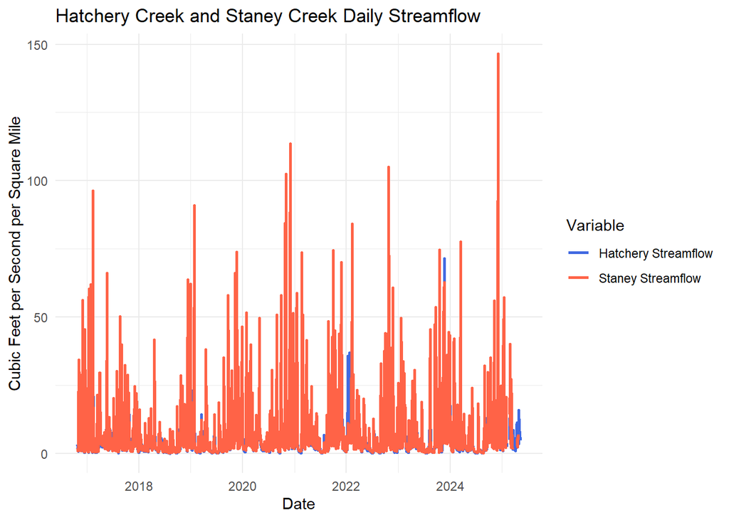

```r
ggplot(discharge, aes(x = Date)) +
  geom_line(aes(y = Hatchery_Discharge, color = "Hatchery Streamflow"), linewidth = 1) +
  geom_line(aes(y = Staney_Discharge, color = "Staney Streamflow"), linewidth = 1) +
  scale_color_manual(values = c("Hatchery Streamflow" = "royalblue", "Staney Streamflow" = "tomato")) +
  labs(title = "Hatchery Creek and Staney Creek Daily Streamflow",
       y = "Cubic Feet per Second per Square Mile",
       color = "Variable") +
  theme_minimal()
```

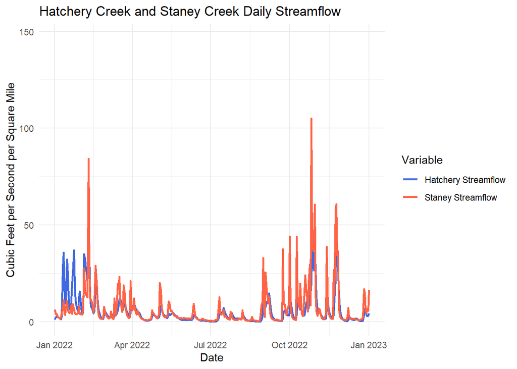

```r
ggplot(discharge, aes(x = Date)) +
  geom_line(aes(y = Hatchery_Discharge, color = "Hatchery Streamflow"), linewidth = 1) +
  geom_line(aes(y = Staney_Discharge, color = "Staney Streamflow"), linewidth = 1) +
  scale_color_manual(values = c("Hatchery Streamflow" = "royalblue", "Staney Streamflow" = "tomato")) +
  scale_x_date(limits = c(ymd(20220101), ymd(20230101))) +
  labs(title = "Hatchery Creek and Staney Creek Daily Streamflow",
       y = "Cubic Feet per Second per Square Mile",
       color = "Variable") +
  theme_minimal()
```

**Figure 3.** Below is another chart of the same data, shortened to a one-year timespan for clarity.

**Stream Flow Flashiness/Baseflow**

```r
staney_baseflow = filtered_staneydischarge %>%
  mutate(Staney_Baseflow = gr_baseflow(Staney_Discharge, method = 'jakeman')) %>%
  filter(Date >= as.Date("2016-10-26") & Date <= as.Date("2025-04-23"))
```

```r
slice_head(staney_baseflow, n = 5)
```

```
        Date Staney_Discharge Staney_Baseflow
1 2016-10-26         1.881391       0.7328456
2 2016-10-27         1.498978       0.7070844
3 2016-10-28         1.280164       0.6818486
4 2016-10-29         1.112474       0.6556400
5 2016-10-30         0.991820       0.6295506
```

**Figure 4.** Above is a table showing the difference in overall flow and baseflow for Staney Creek.

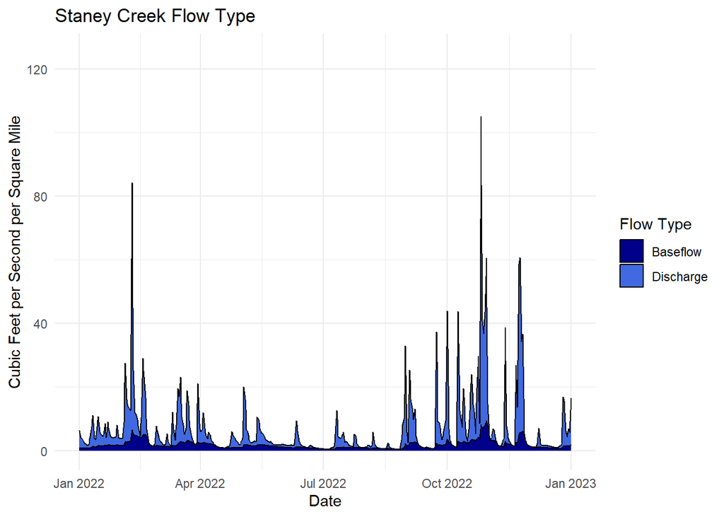

```r
ggplot(staney_baseflow) +
  geom_area(aes(Date, Staney_Discharge, fill = "Discharge"), color = 'black') +
  geom_area(aes(Date, Staney_Baseflow, fill = "Baseflow"), color = 'black') +
  scale_fill_manual(values = c("Discharge" = "royalblue", "Baseflow" = "blue4")) +
  scale_x_date(limits = c(ymd(20220101), ymd(20230101))) +
  theme_minimal() +
  ylim(0, 125) +
  labs(title = "Staney Creek Flow Type",
       y = "Cubic Feet per Second per Square Mile",
       color = "Variable",
       fill = "Flow Type")
```

**Figure 5.** Above is a plot of the flow type for Staney Creek, showing only data from 2022 for clarity. Notice how its data range surpasses 100 cubic feet per second per square mile.

```r
hatchery_baseflow <- hatchery_discharge %>%
  mutate(Hatchery_Baseflow = gr_baseflow(Hatchery_Discharge, method = 'jakeman')) %>%
  filter(Date >= as.Date("2016-10-26") & Date <= as.Date("2025-04-23"))
```

```r
slice_head(hatchery_baseflow, n = 5)
```

```
        Date Hatchery_Discharge Hatchery_Baseflow
1 2016-10-26           3.435897         0.7889080
2 2016-10-27           2.520513         0.7707747
3 2016-10-28           1.843590         0.7434972
4 2016-10-29           1.389744         0.7126735
5 2016-10-30           1.105128         0.6813043
```

**Figure 6.** Above is a table showing the difference in overall flow and baseflow for Hatchery Creek.

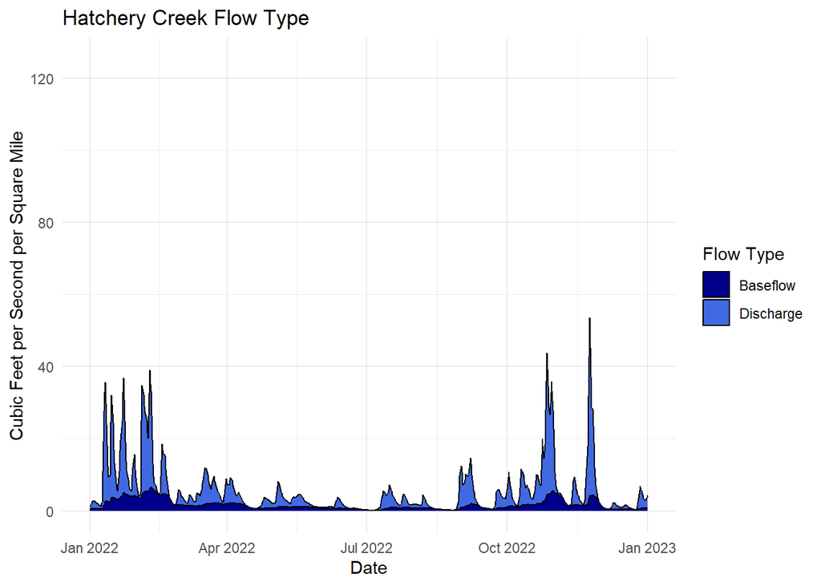

```r
ggplot(hatchery_baseflow) +
  geom_area(aes(Date, Hatchery_Discharge, fill = "Discharge"), color = 'black') +
  geom_area(aes(Date, Hatchery_Baseflow, fill = "Baseflow"), color = 'black') +
  scale_fill_manual(values = c("Discharge" = "royalblue", "Baseflow" = "blue4")) +
  scale_x_date(limits = c(ymd(20220101), ymd(20230101))) +
  ylim(0, 125) +
  theme_minimal() +
  labs(title = "Hatchery Creek Flow Type",
       y = "Cubic Feet per Second per Square Mile",
       color = "Variable",
       fill = "Flow Type")
```

**Figure 7.** Above is a plot of the flow type for Hatchery Creek, showing only data from 2022 for clarity. Notice how its data range doesn’t surpass even 60 cubic feet per second per square mile, a little over half of the maximum in the data range for Staney Creek.

**Stream Temperature**

```r
staney_temp <- readNWISdv(siteNumber = "15081497",    # Download data from USGS for site 06752260
                          parameterCd = "00010") %>%
  select(Date, Staney_Temperature = X_00010_00003)
```

```
GET:https://waterservices.usgs.gov/nwis/dv/?site=15081497&format=waterml%2C1.1&ParameterCd=00010&StatCd=00003&startDT=1851-01-01
```

```r
filtered_staneytemp <- staney_temp %>%
  filter(Date >= as.Date("2017-04-25") & Date <= as.Date("2025-04-23"))
```

```r
hatchery_temp <- readNWISdv(siteNumber = "15086225",
                            parameterCd = "00010") %>%
  select(Date, Hatchery_Temperature = X_00010_00003)
```

```
GET:https://waterservices.usgs.gov/nwis/dv/?site=15086225&format=waterml%2C1.1&ParameterCd=00010&StatCd=00003&startDT=1851-01-01
```

```r
filtered_hatcherytemp <- hatchery_temp %>%
  filter(Date >= as.Date("2017-04-25") & Date <= as.Date("2025-04-23"))
```

```r
stream_temps <- full_join(filtered_hatcherytemp, filtered_staneytemp, by = "Date") %>%
  arrange(Date)
```

```r
slice_head(stream_temps, n = 5)
```

```
        Date Hatchery_Temperature Staney_Temperature
1 2017-04-25                 11.4                6.9
2 2017-04-26                 11.0                7.6
3 2017-04-27                 10.2                6.5
4 2017-04-28                 10.3                5.9
5 2017-04-29                  9.9                5.2
```

**Figure 8.** Above are temperature readings for Hatchery Creek and Staney Creek.

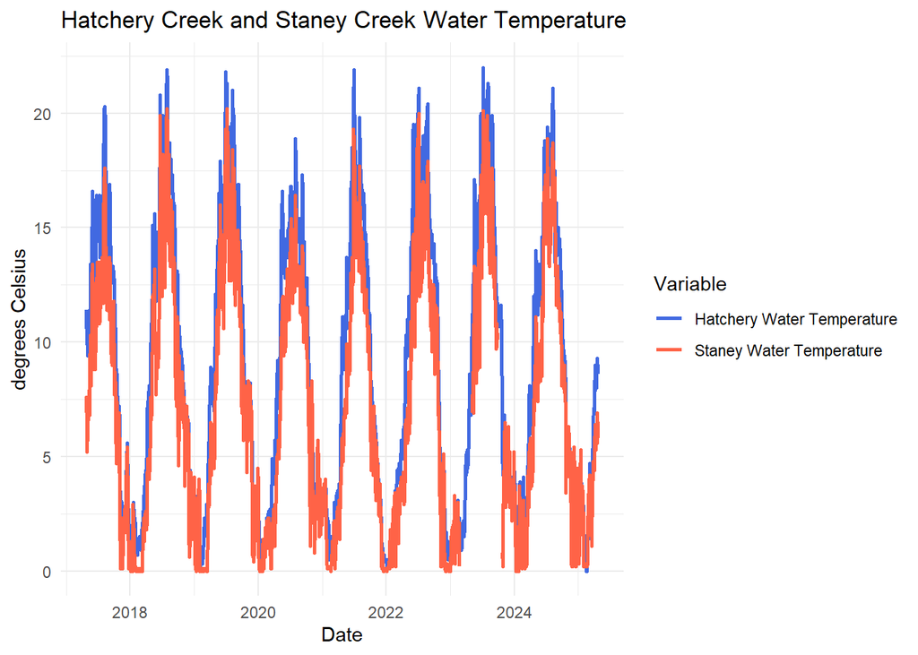

```r
ggplot(stream_temps, aes(x = Date)) +
  geom_line(aes(y = Hatchery_Temperature, color = "Hatchery Water Temperature"), linewidth = 1) +
  geom_line(aes(y = Staney_Temperature, color = "Staney Water Temperature"), linewidth = 1) +
   scale_color_manual(values = c("Hatchery Water Temperature" = "royalblue", "Staney Water Temperature" = "tomato")) +
  labs(title = "Hatchery Creek and Staney Creek Water Temperature",
       y = "degrees Celsius",
       color = "Variable") +
  theme_minimal()
```

**Figure 9.** Above is a graph of temperature readings for Staney Creek and Hatchery Creek, taken between 2017 and 2025.

**Discussion**

According to the water temperature readings shown in Figure 9, both creeks show similar seasonal trends, with temperatures rising in the summer and falling in the winter. However, Staney Creek sometimes has slightly cooler summer temperatures, which was surprising. Disturbed areas usually have warmer water because there’s less shade from trees. This difference might be explained by factors like stream depth, groundwater input, or forest regrowth providing some shade.

These findings suggest that even decades after logging, deforestation continues to affect how a watershed functions. Streamflow patterns especially seem to be shaped by past disturbances, which is important to understand when making decisions about land and forest management.

**Limitations**

One limitation of our analysis is that we only used daily data, which may miss short-term changes like sudden, hourslong spikes during heavy rain. We also didn’t include land cover or precipitation data, which could help explain some of the streamflow differences more clearly.

**Broader Implications**

This project shows how various data science tools can help us understand environmental change. By using public data and tidyverse packages in R, we were able to explore long-term trends in two different creeks. These kinds of analyses are incredibly valuable for conservation efforts and for understanding how ecosystems recover after human disturbances.

**Next Steps**

Future work could bring in data on rainfall, vegetation, or biodiversity to see how streamflow changes affect wildlife and forest recovery. Looking at things like sediment levels or fish populations could also give us a better idea of how these watersheds are doing overall.